# DS 6372: Applied Statistics - Project 2

03/23/2019

The following data set is a breast cancer data set that has numerous measurements taken from tumor biopsies. The goal of using this data set is to predict using the metrics alone if the biopsy is cancer or not. When continuous variables are available it is often helpful to create a pairs plot of data color coded by the response status (Diagnostis). The first variable is an id number and is not needed.

```
##    id_number         diagnosis  radius_mean      texture_mean
##  Min.   :     8670   B:357     Min.   : 6.981   Min.   : 9.71
##  1st Qu.:   869218   M:212     1st Qu.:11.700   1st Qu.:16.17
##  Median :   906024             Median :13.370   Median :18.84
##  Mean   : 30371831             Mean   :14.127   Mean   :19.29
##  3rd Qu.:  8813129             3rd Qu.:15.780   3rd Qu.:21.80
##  Max.   :911320502             Max.   :28.110   Max.   :39.28
##  perimeter_mean     area_mean      smoothness_mean   compactness_mean
##  Min.   : 43.79   Min.   : 143.5   Min.   :0.05263   Min.   :0.01938
##  1st Qu.: 75.17   1st Qu.: 420.3   1st Qu.:0.08637   1st Qu.:0.06492
##  Median : 86.24   Median : 551.1   Median :0.09587   Median :0.09263
##  Mean   : 91.97   Mean   : 654.9   Mean   :0.09636   Mean   :0.10434
##  3rd Qu.:104.10   3rd Qu.: 782.7   3rd Qu.:0.10530   3rd Qu.:0.13040
##  Max.   :188.50   Max.   :2501.0   Max.   :0.16340   Max.   :0.34540
##  concavity_mean    concave_points_mean symmetry_mean
##  Min.   :0.00000   Min.   :0.00000     Min.   :0.1060
##  1st Qu.:0.02956   1st Qu.:0.02031     1st Qu.:0.1619
##  Median :0.06154   Median :0.03350     Median :0.1792
##  Mean   :0.08880   Mean   :0.04892     Mean   :0.1812
##  3rd Qu.:0.13070   3rd Qu.:0.07400     3rd Qu.:0.1957
##  Max.   :0.42680   Max.   :0.20120     Max.   :0.3040
##  fractal_dimension_mean   radius_se        texture_se      perimeter_se
##  Min.   :0.04996        Min.   :0.1115   Min.   :0.3602   Min.   : 0.757
##  1st Qu.:0.05770        1st Qu.:0.2324   1st Qu.:0.8339   1st Qu.: 1.606
##  Median :0.06154        Median :0.3242   Median :1.1080   Median : 2.287
##  Mean   :0.06280        Mean   :0.4052   Mean   :1.2169   Mean   : 2.866
##  3rd Qu.:0.06612        3rd Qu.:0.4789   3rd Qu.:1.4740   3rd Qu.: 3.357
##  Max.   :0.09744        Max.   :2.8730   Max.   :4.8850   Max.   :21.980
##     area_se        smoothness_se      compactness_se      concavity_se
##  Min.   :  6.802   Min.   :0.001713   Min.   :0.002252   Min.   :0.00000
##  1st Qu.: 17.850   1st Qu.:0.005169   1st Qu.:0.013080   1st Qu.:0.01509
##  Median : 24.530   Median :0.006380   Median :0.020450   Median :0.02589
##  Mean   : 40.337   Mean   :0.007041   Mean   :0.025478   Mean   :0.03189
##  3rd Qu.: 45.190   3rd Qu.:0.008146   3rd Qu.:0.032450   3rd Qu.:0.04205
##  Max.   :542.200   Max.   :0.031130   Max.   :0.135400   Max.   :0.39600
##  concave_points_se   symmetry_se       fractal_dimension_se
##  Min.   :0.000000   Min.   :0.007882   Min.   :0.0008948
##  1st Qu.:0.007638   1st Qu.:0.015160   1st Qu.:0.0022480
##  Median :0.010930   Median :0.018730   Median :0.0031870
##  Mean   :0.011796   Mean   :0.020542   Mean   :0.0037949
```

[output cut: 8 more lines]

```
##  Max.   :36.04   Max.   :49.54   Max.   :251.20   Max.   :4254.0
##  smoothness_worst  compactness_worst concavity_worst  concave_points_worst
##  Min.   :0.07117   Min.   :0.02729   Min.   :0.0000   Min.   :0.00000
##  1st Qu.:0.11660   1st Qu.:0.14720   1st Qu.:0.1145   1st Qu.:0.06493
##  Median :0.13130   Median :0.21190   Median :0.2267   Median :0.09993
##  Mean   :0.13237   Mean   :0.25427   Mean   :0.2722   Mean   :0.11461
##  3rd Qu.:0.14600   3rd Qu.:0.33910   3rd Qu.:0.3829   3rd Qu.:0.16140
##  Max.   :0.22260   Max.   :1.05800   Max.   :1.2520   Max.   :0.29100
##  symmetry_worst   fractal_dimension_worst
##  Min.   :0.1565   Min.   :0.05504
##  1st Qu.:0.2504   1st Qu.:0.07146
##  Median :0.2822   Median :0.08004
##  Mean   :0.2901   Mean   :0.08395
##  3rd Qu.:0.3179   3rd Qu.:0.09208
##  Max.   :0.6638   Max.   :0.20750
```

```
##  diagnosis  radius_mean      texture_mean    perimeter_mean
##  B:357     Min.   :0.0000   Min.   :0.0000   Min.   :0.0000
##  M:212     1st Qu.:0.2233   1st Qu.:0.2185   1st Qu.:0.2168
##            Median :0.3024   Median :0.3088   Median :0.2933
##            Mean   :0.3382   Mean   :0.3240   Mean   :0.3329
##            3rd Qu.:0.4164   3rd Qu.:0.4089   3rd Qu.:0.4168
##            Max.   :1.0000   Max.   :1.0000   Max.   :1.0000
##    area_mean      smoothness_mean  compactness_mean concavity_mean
##  Min.   :0.0000   Min.   :0.0000   Min.   :0.0000   Min.   :0.00000
##  1st Qu.:0.1174   1st Qu.:0.3046   1st Qu.:0.1397   1st Qu.:0.06926
##  Median :0.1729   Median :0.3904   Median :0.2247   Median :0.14419
##  Mean   :0.2169   Mean   :0.3948   Mean   :0.2606   Mean   :0.20806
##  3rd Qu.:0.2711   3rd Qu.:0.4755   3rd Qu.:0.3405   3rd Qu.:0.30623
##  Max.   :1.0000   Max.   :1.0000   Max.   :1.0000   Max.   :1.00000
##  concave_points_mean symmetry_mean    fractal_dimension_mean
##  Min.   :0.0000      Min.   :0.0000   Min.   :0.0000
##  1st Qu.:0.1009      1st Qu.:0.2823   1st Qu.:0.1630
##  Median :0.1665      Median :0.3697   Median :0.2439
##  Mean   :0.2431      Mean   :0.3796   Mean   :0.2704
##  3rd Qu.:0.3678      3rd Qu.:0.4530   3rd Qu.:0.3404
##  Max.   :1.0000      Max.   :1.0000   Max.   :1.0000
##    radius_se         texture_se      perimeter_se        area_se
##  Min.   :0.00000   Min.   :0.0000   Min.   :0.00000   Min.   :0.00000
##  1st Qu.:0.04378   1st Qu.:0.1047   1st Qu.:0.04000   1st Qu.:0.02064
##  Median :0.07702   Median :0.1653   Median :0.07209   Median :0.03311
##  Mean   :0.10635   Mean   :0.1893   Mean   :0.09938   Mean   :0.06264
##  3rd Qu.:0.13304   3rd Qu.:0.2462   3rd Qu.:0.12251   3rd Qu.:0.07170
##  Max.   :1.00000   Max.   :1.0000   Max.   :1.00000   Max.   :1.00000
##  smoothness_se    compactness_se     concavity_se     concave_points_se
##  Min.   :0.0000   Min.   :0.00000   Min.   :0.00000   Min.   :0.0000
##  1st Qu.:0.1175   1st Qu.:0.08132   1st Qu.:0.03811   1st Qu.:0.1447
##  Median :0.1586   Median :0.13667   Median :0.06538   Median :0.2070
##  Mean   :0.1811   Mean   :0.17444   Mean   :0.08054   Mean   :0.2235
##  3rd Qu.:0.2187   3rd Qu.:0.22680   3rd Qu.:0.10619   3rd Qu.:0.2787
##  Max.   :1.0000   Max.   :1.00000   Max.   :1.00000   Max.   :1.0000
##   symmetry_se     fractal_dimension_se  radius_worst    texture_worst
##  Min.   :0.0000   Min.   :0.00000      Min.   :0.0000   Min.   :0.0000
##  1st Qu.:0.1024   1st Qu.:0.04675      1st Qu.:0.1807   1st Qu.:0.2415
##  Median :0.1526   Median :0.07919      Median :0.2504   Median :0.3569
##  Mean   :0.1781   Mean   :0.10019      Mean   :0.2967   Mean   :0.3640
```

[output cut: 8 more lines]

```
##  Max.   :1.0000   Max.   :1.00000   Max.   :1.0000   Max.   :1.0000
##  concavity_worst   concave_points_worst symmetry_worst
##  Min.   :0.00000   Min.   :0.0000       Min.   :0.0000
##  1st Qu.:0.09145   1st Qu.:0.2231       1st Qu.:0.1851
##  Median :0.18107   Median :0.3434       Median :0.2478
##  Mean   :0.21740   Mean   :0.3938       Mean   :0.2633
##  3rd Qu.:0.30583   3rd Qu.:0.5546       3rd Qu.:0.3182
##  Max.   :1.00000   Max.   :1.0000       Max.   :1.0000
##  fractal_dimension_worst
##  Min.   :0.0000
##  1st Qu.:0.1077
##  Median :0.1640
##  Mean   :0.1896
##  3rd Qu.:0.2429
##  Max.   :1.0000
```

```
##
##   B   M
## 357 212
```

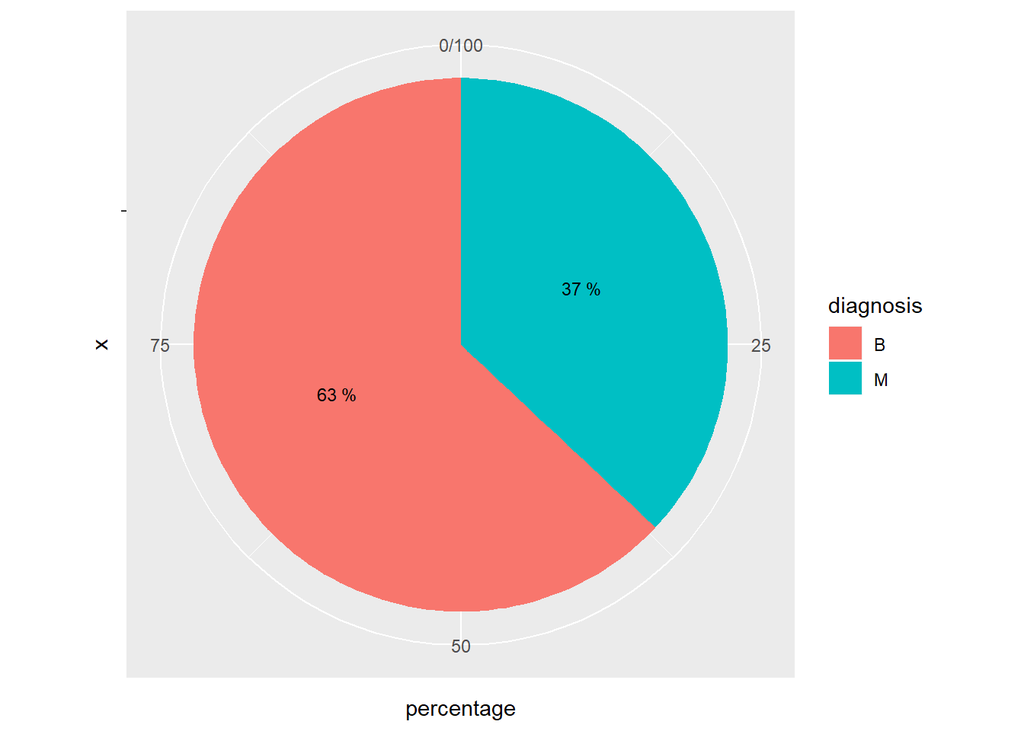

## SCATTERPLOTS SHOWING CORRELATION

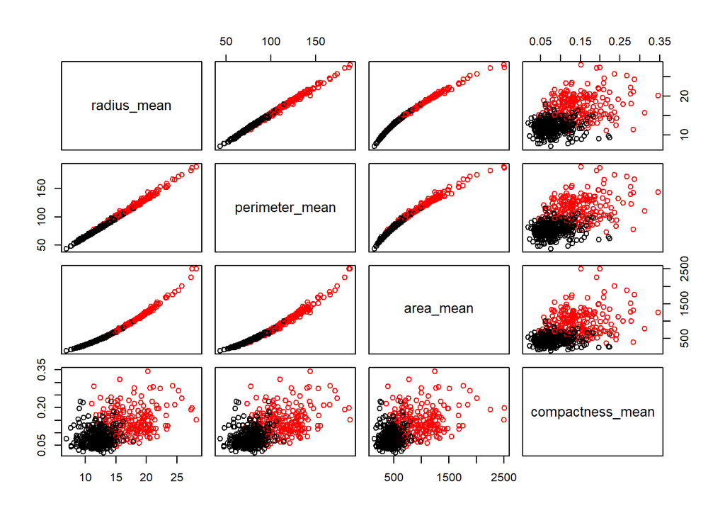

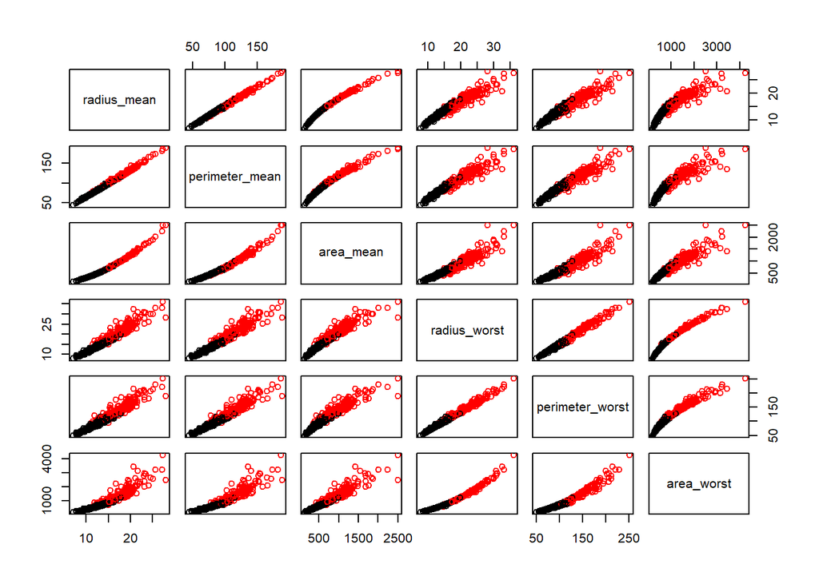

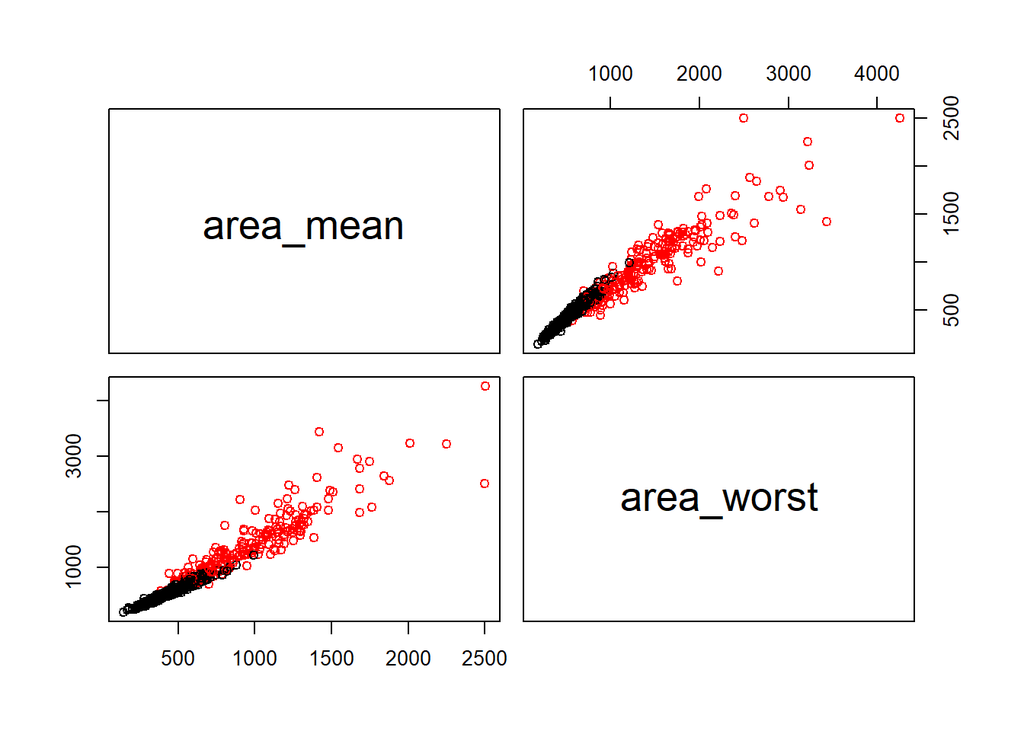

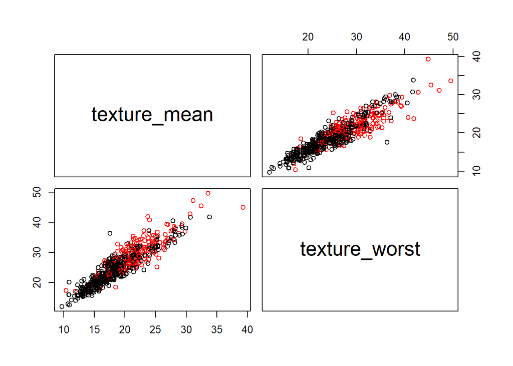

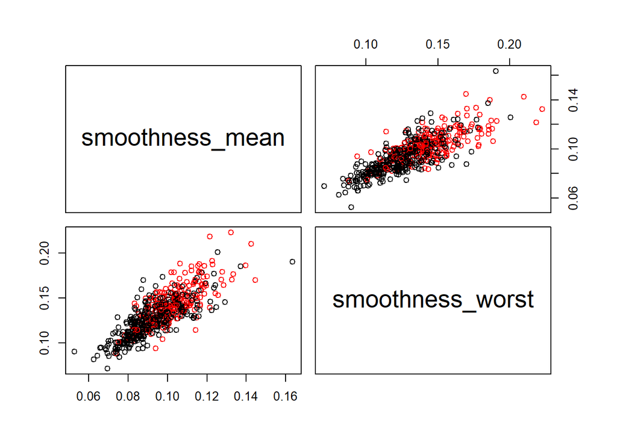

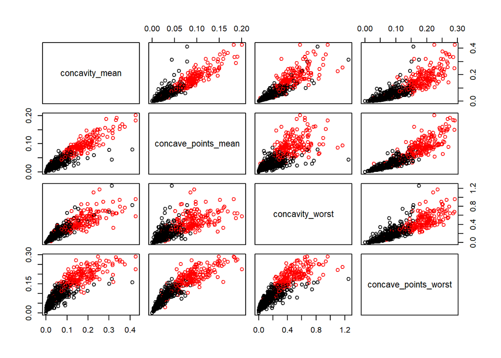

## ADDING BOX PLOTS

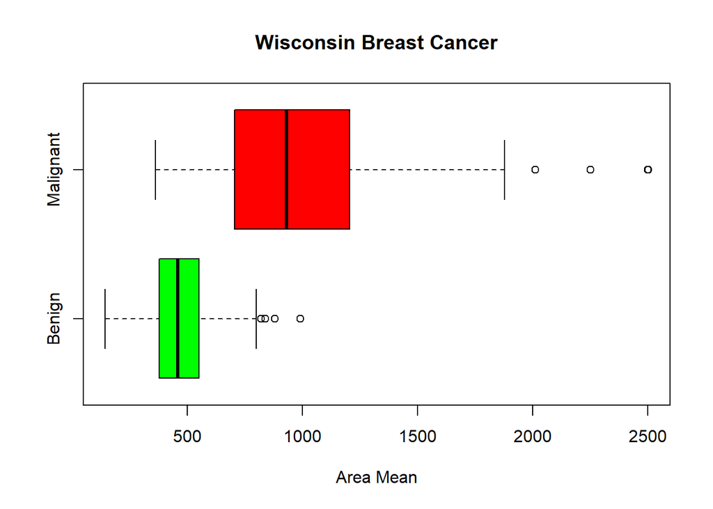

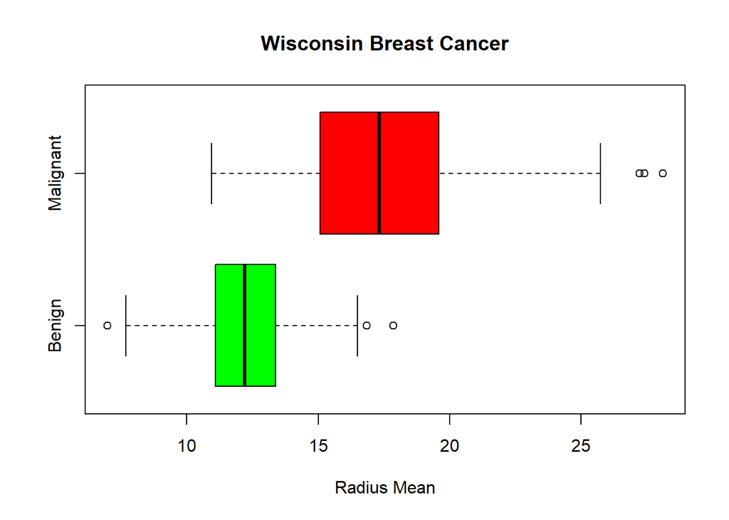

So we can see from this pairs plot of just the first few variables, seperation between the cancer and non cancer groups are pretty well seperated. Unfortunately we may not always see clear seperations but that does not necesarily mean that something like LDA or some other predcictive tool won’t work. It could be due to the fact we cant see the seperation of the groups unless we can actually see in higher dimensions. One way to still get at this, is to conduct a PCA analysis and provide a some scatterplots for the first few PC’s. If seperation exists in the PC’s, then a predictive model will probably do well.

Below we will conduct PCA on all of the predictors and plot the first few PC’s against each other and look for speration. The number of PCs to explore can be dictated by the scree plot.

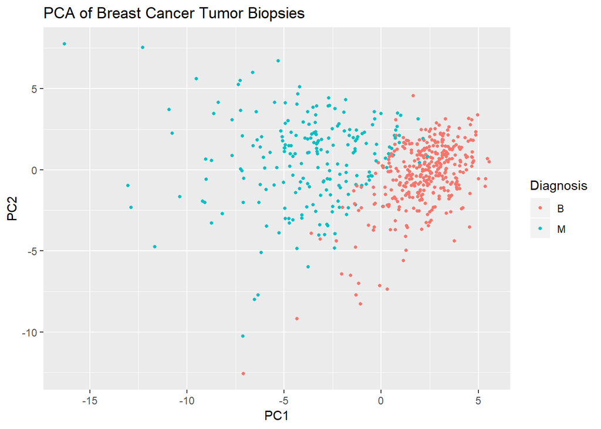

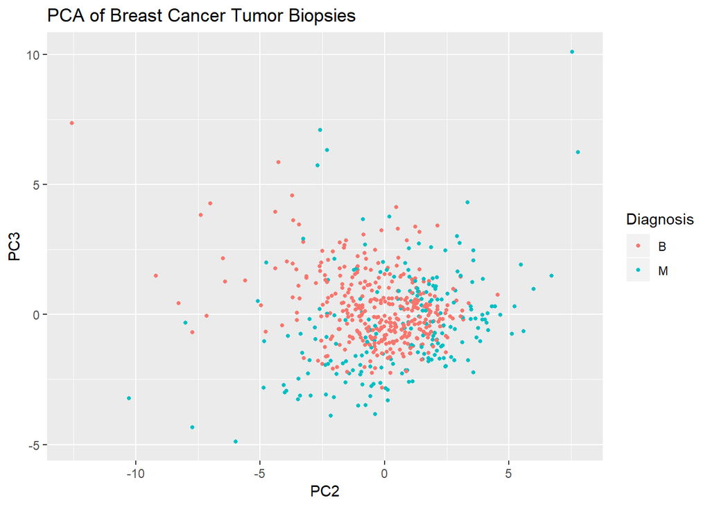

So we can see in the first graphic a clear seperation exists for the two cancer groups. So the PCA is telling us in effect what we already know from looking at the original variables. The power of this approach is that you only need to look at 2-4 graphs each time, versus potentially having to examine massive scatterplot matrices to see if anything is there or not!

```
##
## prd   B   M
##   B 356  27
##   M   1 185
```

Seeing how a lot of the attributes are strongly correlated, we will use PCA to convert attributes into a set of uncorrelated components.

## Adding the response column to the PC’s data frame

```
## Importance of components:
##                           Comp.1    Comp.2     Comp.3     Comp.4
## Standard deviation     0.5751101 0.3281171 0.21051526 0.19984110
## Proportion of Variance 0.5309769 0.1728349 0.07114442 0.06411259
## Cumulative Proportion  0.5309769 0.7038118 0.77495621 0.83906880
##                            Comp.5     Comp.6     Comp.7     Comp.8
## Standard deviation     0.15953874 0.13832097 0.09923315 0.08614995
## Proportion of Variance 0.04086072 0.03071494 0.01580837 0.01191472
## Cumulative Proportion  0.87992952 0.91064446 0.92645284 0.93836755
##                             Comp.9     Comp.10     Comp.11     Comp.12
## Standard deviation     0.078466796 0.076741723 0.072739180 0.068713333
## Proportion of Variance 0.009884291 0.009454461 0.008493966 0.007579765
## Cumulative Proportion  0.948251845 0.957706306 0.966200271 0.973780036
##                            Comp.13     Comp.14     Comp.15     Comp.16
## Standard deviation     0.063955251 0.054384326 0.040966679 0.040069717
## Proportion of Variance 0.006566381 0.004748115 0.002694233 0.002577545
## Cumulative Proportion  0.980346417 0.985094532 0.987788765 0.990366310
##                            Comp.17     Comp.18     Comp.19     Comp.20
## Standard deviation     0.033832449 0.030696718 0.029289317 0.025691093
## Proportion of Variance 0.001837556 0.001512717 0.001377185 0.001059592
## Cumulative Proportion  0.992203866 0.993716583 0.995093767 0.996153360
##                            Comp.21      Comp.22    Comp.23      Comp.24
## Standard deviation     0.024745908 0.0221059201 0.01813656 0.0178234826
## Proportion of Variance 0.000983061 0.0007844963 0.00052806 0.0005099867
## Cumulative Proportion  0.997136421 0.9979209169 0.99844898 0.9989589637
##                             Comp.25      Comp.26     Comp.27      Comp.28
## Standard deviation     0.0163675776 0.0143290755 0.010895447 5.901461e-03
## Proportion of Variance 0.0004300733 0.0003296173 0.000190574 5.591043e-05
## Cumulative Proportion  0.9993890370 0.9997186543 0.999909228 9.999651e-01
##                             Comp.29      Comp.30
## Standard deviation     4.242650e-03 1.927531e-03
## Proportion of Variance 2.889669e-05 5.964532e-06
## Cumulative Proportion  9.999940e-01 1.000000e+00
```

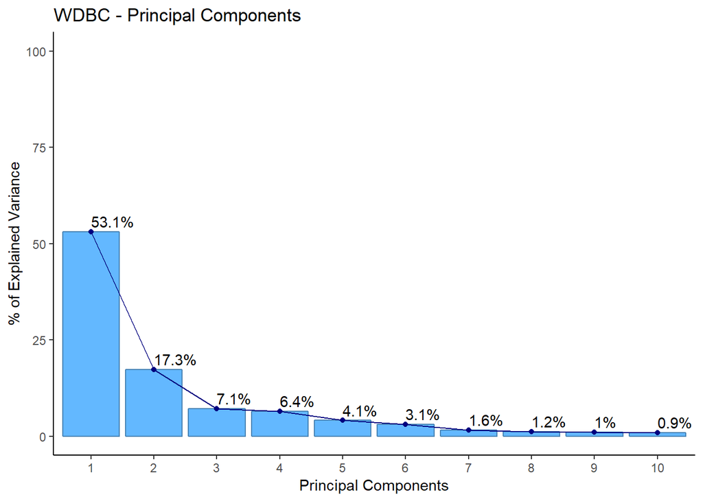

## LOGISTIC GLM: MAIN MODEL

```
##
## Call:
## glm(formula = diagnosis ~ ., family = binomial(link = "logit"),
##     data = bc.clean)
##
## Deviance Residuals:
##    Min      1Q  Median      3Q     Max
##  -8.49   -8.49   -8.49    8.49    8.49
##
## Coefficients:
##                           Estimate Std. Error z value Pr(>|z|)
## (Intercept)             -2.881e+06  2.816e+05 -10.233  < 2e-16 ***
## radius_mean              2.427e+06  2.693e+05   9.014  < 2e-16 ***
## texture_mean             1.958e+05  1.471e+04  13.313  < 2e-16 ***
## perimeter_mean           1.473e+06  2.464e+04  59.791  < 2e-16 ***
## area_mean               -1.301e+05  3.907e+03 -33.301  < 2e-16 ***
## smoothness_mean         -1.525e+08  8.361e+06 -18.234  < 2e-16 ***
## compactness_mean        -6.428e+06  3.213e+06  -2.001  0.04540 *
## concavity_mean           1.042e+06  1.408e+06   0.740  0.45959
## concave_points_mean     -1.716e+07  5.382e+06  -3.188  0.00143 **
## symmetry_mean            4.049e+07  7.772e+05  52.093  < 2e-16 ***
## fractal_dimension_mean  -4.233e+07  2.169e+06 -19.519  < 2e-16 ***
## radius_se                3.328e+07  1.169e+06  28.478  < 2e-16 ***
## texture_se               6.368e+06  2.005e+05  31.763  < 2e-16 ***
## perimeter_se             1.701e+06  4.720e+04  36.032  < 2e-16 ***
## area_se                 -6.393e+05  1.835e+04 -34.840  < 2e-16 ***
## smoothness_se            7.492e+08  1.224e+07  61.213  < 2e-16 ***
## compactness_se          -1.773e+08  5.732e+06 -30.931  < 2e-16 ***
## concavity_se             1.529e+08  5.340e+06  28.624  < 2e-16 ***
## concave_points_se       -1.260e+09  4.012e+07 -31.398  < 2e-16 ***
## symmetry_se              2.890e+08  4.126e+06  70.054  < 2e-16 ***
## fractal_dimension_se     1.512e+09  6.597e+07  22.921  < 2e-16 ***
## radius_worst            -6.130e+06  2.143e+05 -28.606  < 2e-16 ***
## texture_worst           -5.832e+05  2.437e+04 -23.935  < 2e-16 ***
## perimeter_worst         -3.538e+05  1.219e+04 -29.023  < 2e-16 ***
## area_worst               8.950e+04  2.741e+03  32.657  < 2e-16 ***
## smoothness_worst        -2.161e+07  3.298e+06  -6.553 5.66e-11 ***
## compactness_worst        8.986e+06  3.999e+05  22.470  < 2e-16 ***
## concavity_worst         -3.028e+07  1.523e+06 -19.875  < 2e-16 ***
## concave_points_worst     1.431e+08  5.471e+06  26.162  < 2e-16 ***
## symmetry_worst          -2.474e+07  3.392e+05 -72.923  < 2e-16 ***
## fractal_dimension_worst -3.698e+07  5.340e+06  -6.926 4.33e-12 ***
## ---
## Signif. codes:  0 '***' 0.001 '**' 0.01 '*' 0.05 '.' 0.1 ' ' 1
##
## (Dispersion parameter for binomial family taken to be 1)
##
##     Null deviance:   751.44  on 568  degrees of freedom
## Residual deviance: 32006.76  on 538  degrees of freedom
## AIC: 32069
##
## Number of Fisher Scoring iterations: 25
```

Notice the VIF scores are incredibly high since radius, perimeter, and area are all a function of each other

```
##             radius_mean            texture_mean          perimeter_mean
##             4318064.819              140816.301             1691914.115
##               area_mean         smoothness_mean        compactness_mean
##             6331654.556              213016.630              415839.480
##          concavity_mean     concave_points_mean           symmetry_mean
##              105593.175              192381.209               11851.056
##  fractal_dimension_mean               radius_se              texture_se
##                3513.137              610335.654              356773.155
##            perimeter_se                 area_se           smoothness_se
##               49276.838             1109444.271               41333.693
##          compactness_se            concavity_se       concave_points_se
##              473636.452              778242.166             1574955.424
##             symmetry_se    fractal_dimension_se            radius_worst
##               24678.711              463075.232             3511809.022
##           texture_worst         perimeter_worst              area_worst
##              823081.453              617752.520             4767646.724
##        smoothness_worst       compactness_worst         concavity_worst
##               58738.806               91238.173             1705825.343
##    concave_points_worst          symmetry_worst fractal_dimension_worst
##              561062.026               10409.339              193961.544
```

## LOGISTIC GLM: NORMALIZED DATA

Note the same issue persists even after data has been normalized

```
##
## Call:
## glm(formula = diagnosis ~ ., family = binomial(link = "logit"),
##     data = bc.clean)
##
## Deviance Residuals:
##    Min      1Q  Median      3Q     Max
##  -8.49   -8.49   -8.49    8.49    8.49
##
## Coefficients:
##                           Estimate Std. Error z value Pr(>|z|)
## (Intercept)             -2.881e+06  2.816e+05 -10.233  < 2e-16 ***
## radius_mean              2.427e+06  2.693e+05   9.014  < 2e-16 ***
## texture_mean             1.958e+05  1.471e+04  13.313  < 2e-16 ***
## perimeter_mean           1.473e+06  2.464e+04  59.791  < 2e-16 ***
## area_mean               -1.301e+05  3.907e+03 -33.301  < 2e-16 ***
## smoothness_mean         -1.525e+08  8.361e+06 -18.234  < 2e-16 ***
## compactness_mean        -6.428e+06  3.213e+06  -2.001  0.04540 *
## concavity_mean           1.042e+06  1.408e+06   0.740  0.45959
## concave_points_mean     -1.716e+07  5.382e+06  -3.188  0.00143 **
## symmetry_mean            4.049e+07  7.772e+05  52.093  < 2e-16 ***
## fractal_dimension_mean  -4.233e+07  2.169e+06 -19.519  < 2e-16 ***
## radius_se                3.328e+07  1.169e+06  28.478  < 2e-16 ***
## texture_se               6.368e+06  2.005e+05  31.763  < 2e-16 ***
## perimeter_se             1.701e+06  4.720e+04  36.032  < 2e-16 ***
## area_se                 -6.393e+05  1.835e+04 -34.840  < 2e-16 ***
## smoothness_se            7.492e+08  1.224e+07  61.213  < 2e-16 ***
## compactness_se          -1.773e+08  5.732e+06 -30.931  < 2e-16 ***
## concavity_se             1.529e+08  5.340e+06  28.624  < 2e-16 ***
## concave_points_se       -1.260e+09  4.012e+07 -31.398  < 2e-16 ***
## symmetry_se              2.890e+08  4.126e+06  70.054  < 2e-16 ***
## fractal_dimension_se     1.512e+09  6.597e+07  22.921  < 2e-16 ***
## radius_worst            -6.130e+06  2.143e+05 -28.606  < 2e-16 ***
## texture_worst           -5.832e+05  2.437e+04 -23.935  < 2e-16 ***
## perimeter_worst         -3.538e+05  1.219e+04 -29.023  < 2e-16 ***
## area_worst               8.950e+04  2.741e+03  32.657  < 2e-16 ***
## smoothness_worst        -2.161e+07  3.298e+06  -6.553 5.66e-11 ***
## compactness_worst        8.986e+06  3.999e+05  22.470  < 2e-16 ***
## concavity_worst         -3.028e+07  1.523e+06 -19.875  < 2e-16 ***
## concave_points_worst     1.431e+08  5.471e+06  26.162  < 2e-16 ***
## symmetry_worst          -2.474e+07  3.392e+05 -72.923  < 2e-16 ***
## fractal_dimension_worst -3.698e+07  5.340e+06  -6.926 4.33e-12 ***
## ---
## Signif. codes:  0 '***' 0.001 '**' 0.01 '*' 0.05 '.' 0.1 ' ' 1
##
## (Dispersion parameter for binomial family taken to be 1)
##
##     Null deviance:   751.44  on 568  degrees of freedom
## Residual deviance: 32006.76  on 538  degrees of freedom
## AIC: 32069
##
## Number of Fisher Scoring iterations: 25
```

```
##             radius_mean            texture_mean          perimeter_mean
##             3806.115296               11.884048             3786.400419
##               area_mean         smoothness_mean        compactness_mean
##              347.878657                8.194282               50.505168
##          concavity_mean     concave_points_mean           symmetry_mean
##               70.767720               60.041733                4.220656
##  fractal_dimension_mean               radius_se              texture_se
##               15.756977               75.462027                4.205423
##            perimeter_se                 area_se           smoothness_se
##               70.359695               41.163091                4.027923
##          compactness_se            concavity_se       concave_points_se
##               15.366324               15.694833               11.520796
##             symmetry_se    fractal_dimension_se            radius_worst
##                5.175426                9.717987              799.105946
##           texture_worst         perimeter_worst              area_worst
##               18.569966              405.023336              337.221924
##        smoothness_worst       compactness_worst         concavity_worst
##               10.923061               36.982755               31.970723
##    concave_points_worst          symmetry_worst fractal_dimension_worst
##               36.763714                9.520570               18.861533
```

## LOGISTIC GLM: REDUCED MODEL

Looking at the scatterplots above in the EDA section we can simplify the model based on the correlation we see

```
##
## Call:
## glm(formula = diagnosis ~ texture_mean + area_mean + smoothness_mean +
##     compactness_mean + concavity_mean + concave_points_mean +
##     symmetry_mean + fractal_dimension_mean, family = binomial(link = "logit"),
##     data = bc.clean)
##
## Deviance Residuals:
##      Min        1Q    Median        3Q       Max
## -2.02338  -0.14079  -0.03572   0.01120   3.00158
##
## Coefficients:
##                          Estimate Std. Error z value Pr(>|z|)
## (Intercept)            -27.253090   6.400270  -4.258 2.06e-05 ***
## texture_mean             0.384407   0.063485   6.055 1.40e-09 ***
## area_mean                0.011787   0.002728   4.320 1.56e-05 ***
## smoothness_mean         79.598004  32.979533   2.414   0.0158 *
## compactness_mean       -13.731887  12.700676  -1.081   0.2796
## concavity_mean          13.249936   8.090709   1.638   0.1015
## concave_points_mean     57.230227  28.042055   2.041   0.0413 *
## symmetry_mean           17.779963  10.854712   1.638   0.1014
## fractal_dimension_mean -26.454327  82.469431  -0.321   0.7484
## ---
## Signif. codes:  0 '***' 0.001 '**' 0.01 '*' 0.05 '.' 0.1 ' ' 1
##
## (Dispersion parameter for binomial family taken to be 1)
##
##     Null deviance: 751.44  on 568  degrees of freedom
## Residual deviance: 149.01  on 560  degrees of freedom
## AIC: 167.01
##
## Number of Fisher Scoring iterations: 8
```

```
##           texture_mean              area_mean        smoothness_mean
##               1.764829               3.250272               4.288467
##       compactness_mean         concavity_mean    concave_points_mean
##               5.763065               4.987014               5.744502
##          symmetry_mean fractal_dimension_mean
##               1.823926               8.311224
```

NOTE: R will display a warning message about GLM since all response probabilities are 0 or 1

```
##                                2.5 %       97.5 %
## (Intercept)            -4.053919e+01 -15.31563155
## texture_mean            2.674975e-01   0.51837370
## area_mean               6.757782e-03   0.01749949
## smoothness_mean         1.771586e+01 147.27093557
## compactness_mean       -3.951821e+01  11.10875994
## concavity_mean         -2.529860e+00  29.24616163
## concave_points_mean     3.911450e+00 114.21970795
## symmetry_mean          -3.644306e+00  39.25139134
## fractal_dimension_mean -1.925487e+02 132.60062490
```

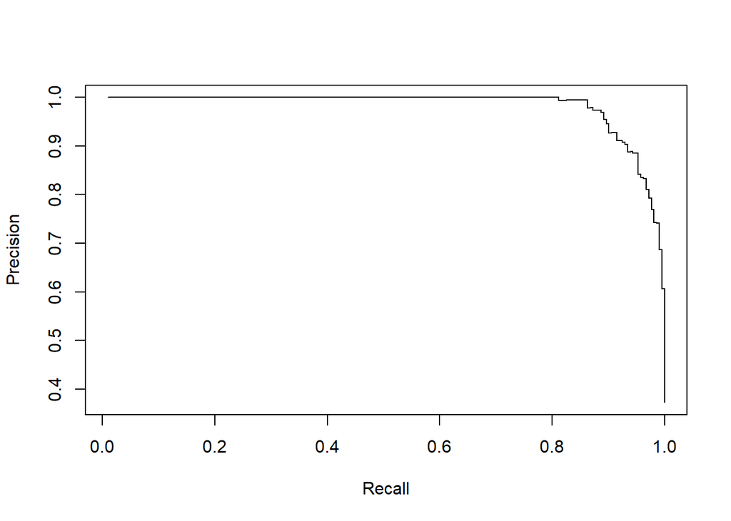

## PLOTTING LOGISTIC REGRESSION REDUX MODEL

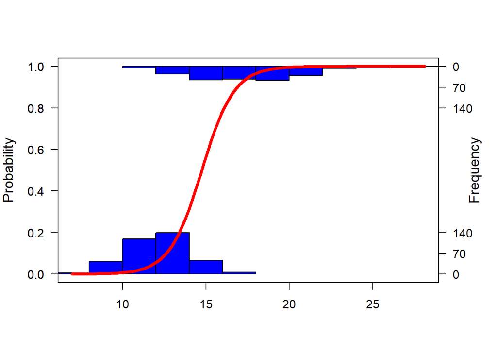

## LOGISTIC GLM: REDUCED + INTERACTIONS

For Objective 2 we will try interactions on the reduced model and see how this effects the AIC score as well as the VIF values

```
## [1] 1449.135
```

[output not shown]

[output cut: 973 more lines]

[output not shown]

## AIC STEPWISE FEATURE SELECTION

Note guys I really REALLY struggled w/ this. The final output is more like the PCA. Has an AIC of 50 but looking at the model it produces and the coefficients, it really looks like its overfitting

```
## Start:  AIC=32068.76
## diagnosis ~ radius_mean + texture_mean + perimeter_mean + area_mean +
##     smoothness_mean + compactness_mean + concavity_mean + concave_points_mean +
##     symmetry_mean + fractal_dimension_mean + radius_se + texture_se +
##     perimeter_se + area_se + smoothness_se + compactness_se +
##     concavity_se + concave_points_se + symmetry_se + fractal_dimension_se +
##     radius_worst + texture_worst + perimeter_worst + area_worst +
##     smoothness_worst + compactness_worst + concavity_worst +
##     concave_points_worst + symmetry_worst + fractal_dimension_worst
##
##                           Df Deviance   AIC LRT Pr(Chi)
## - concave_points_worst     1        0    60   0       1
## - radius_se                1        0    60   0       1
## - perimeter_worst          1        0    60   0       1
## - texture_se               1        0    60   0       1
## - smoothness_se            1        0    60   0       1
## - smoothness_worst         1        0    60   0       1
## - perimeter_mean           1        0    60   0       1
## - texture_mean             1        0    60   0       1
## - smoothness_mean          1        0    60   0       1
## - radius_worst             1        0    60   0       1
## - texture_worst            1        0    60   0       1
## - concave_points_mean      1        0    60   0       1
## - fractal_dimension_mean   1        0    60   0       1
## - perimeter_se             1        0    60   0       1
## - area_mean                1       26    86   0       1
## - symmetry_se              1       27    87   0       1
## - fractal_dimension_worst  1       27    87   0       1
## - symmetry_mean            1       27    87   0       1
## - compactness_se           1       29    89   0       1
## - compactness_mean         1       31    91   0       1
## - symmetry_worst           1       31    91   0       1
## - concave_points_se        1       33    93   0       1
## - fractal_dimension_se     1       34    94   0       1
## - concavity_se             1       36    96   0       1
## - area_worst               1      721   781   0       1
## - area_se                  1      793   853   0       1
## - compactness_worst        1      793   853   0       1
## - concavity_mean           1      865   925   0       1
## - concavity_worst          1     1009  1069   0       1
```

[output cut: 254 more lines]

```
## - concave_points_mean      1    30.64   78.64 30.640 3.106e-08 ***
## - compactness_se           1    30.88   78.88 30.875 2.751e-08 ***
## - texture_mean             1    31.20   79.20 31.203 2.324e-08 ***
## - area_mean                1    32.14   80.14 32.145 1.431e-08 ***
## - area_se                  1    32.51   80.51 32.513 1.184e-08 ***
## - fractal_dimension_worst  1    32.85   80.85 32.852 9.946e-09 ***
## - symmetry_worst           1    33.50   81.50 33.504 7.113e-09 ***
## - radius_mean              1    34.51   82.51 34.507 4.247e-09 ***
## - fractal_dimension_se     1    37.14   85.14 37.143 1.098e-09 ***
## - concavity_se             1    37.62   85.62 37.623 8.583e-10 ***
## - compactness_mean         1    40.35   88.35 40.345 2.128e-10 ***
## - concave_points_se        1    42.69   90.69 42.693 6.403e-11 ***
## + radius_se                1  1009.22 1061.22  0.000    1.0000
## ---
## Signif. codes:  0 '***' 0.001 '**' 0.01 '*' 0.05 '.' 0.1 ' ' 1
```

```
##
## Call:
## glm(formula = diagnosis ~ radius_mean + texture_mean + area_mean +
##     smoothness_mean + compactness_mean + concavity_mean + concave_points_mean +
##     symmetry_mean + fractal_dimension_mean + perimeter_se + area_se +
##     smoothness_se + compactness_se + concavity_se + concave_points_se +
##     symmetry_se + fractal_dimension_se + radius_worst + texture_worst +
##     perimeter_worst + area_worst + concavity_worst + symmetry_worst +
##     fractal_dimension_worst, family = binomial(link = "logit"),
##     data = bc.clean)
##
## Deviance Residuals:
##       Min         1Q     Median         3Q        Max
## -0.003832   0.000000   0.000000   0.000000   0.004291
##
## Coefficients:
##                           Estimate Std. Error z value Pr(>|z|)
## (Intercept)             -5.914e+03  2.619e+05  -0.023    0.982
## radius_mean             -6.630e+03  1.150e+05  -0.058    0.954
## texture_mean             1.913e+02  1.345e+03   0.142    0.887
## area_mean                6.077e+01  1.079e+03   0.056    0.955
## smoothness_mean          3.914e+04  2.517e+05   0.155    0.876
## compactness_mean        -8.621e+04  9.326e+05  -0.092    0.926
## concavity_mean           2.852e+04  2.402e+05   0.119    0.905
## concave_points_mean      5.886e+04  1.544e+06   0.038    0.970
## symmetry_mean           -1.964e+04  1.347e+05  -0.146    0.884
## fractal_dimension_mean   1.626e+05  1.120e+06   0.145    0.885
## perimeter_se            -1.253e+03  1.822e+04  -0.069    0.945
## area_se                  1.562e+02  2.259e+03   0.069    0.945
## smoothness_se           -9.793e+04  1.472e+06  -0.067    0.947
## compactness_se           9.217e+04  7.142e+05   0.129    0.897
## concavity_se            -8.131e+04  1.097e+06  -0.074    0.941
## concave_points_se        4.398e+05  6.736e+06   0.065    0.948
## symmetry_se             -1.038e+05  2.160e+06  -0.048    0.962
## fractal_dimension_se    -1.092e+06  1.065e+07  -0.103    0.918
## radius_worst             2.226e+03  2.134e+04   0.104    0.917
## texture_worst            7.269e+01  3.150e+03   0.023    0.982
## perimeter_worst          1.267e+02  1.355e+03   0.093    0.926
## area_worst              -1.626e+01  1.165e+02  -0.140    0.889
## concavity_worst          6.737e+03  1.051e+05   0.064    0.949
## symmetry_worst           2.201e+04  3.283e+05   0.067    0.947
## fractal_dimension_worst  5.899e+04  1.032e+06   0.057    0.954
##
## (Dispersion parameter for binomial family taken to be 1)
##
##     Null deviance: 7.5144e+02  on 568  degrees of freedom
## Residual deviance: 1.6713e-04  on 544  degrees of freedom
## AIC: 50
##
## Number of Fisher Scoring iterations: 25
```

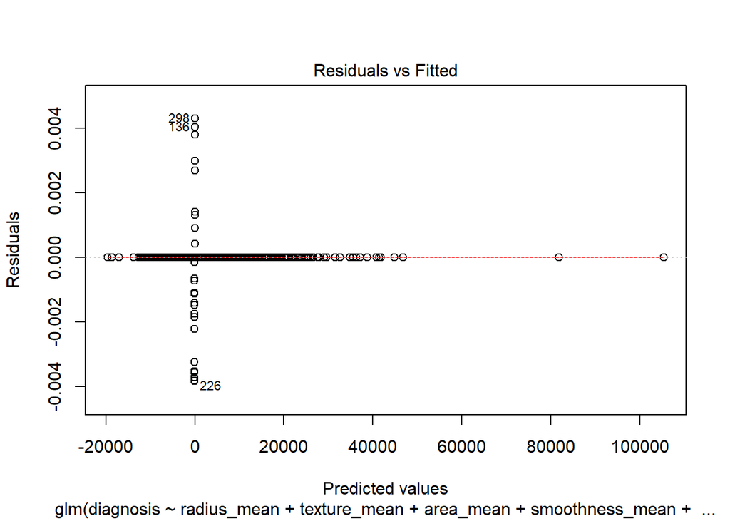

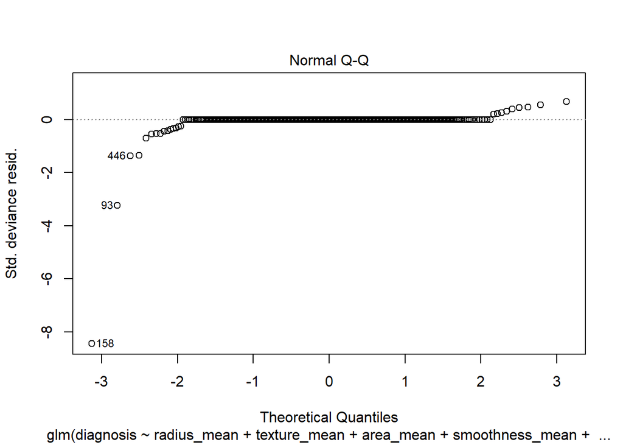

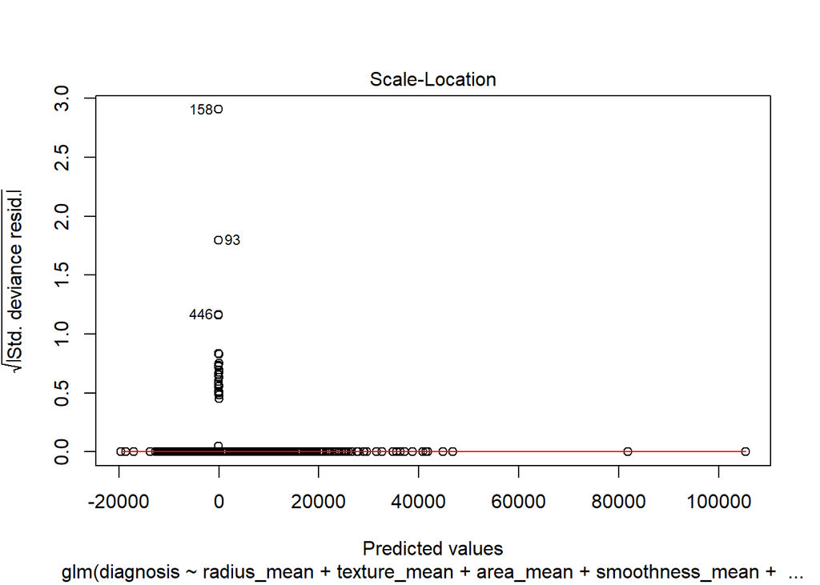

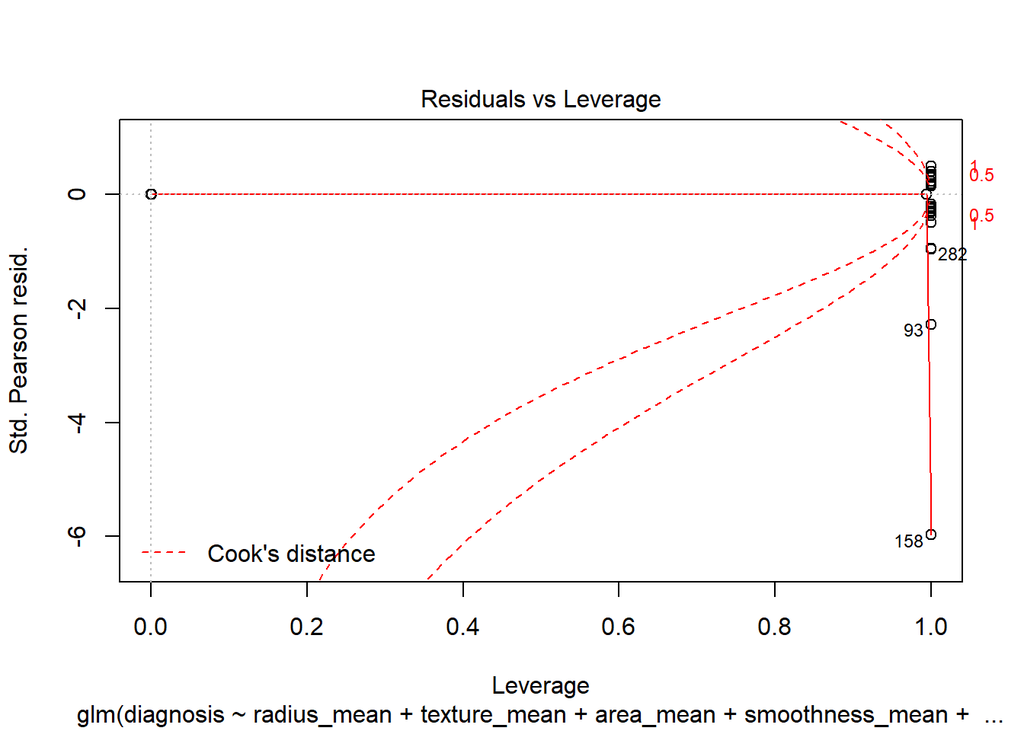

## LASSO GLMNET

```
## [1] 0.001909601
```

Output the final coefficients from GLMNET LASSO

```
## 31 x 1 sparse Matrix of class "dgCMatrix"
##                                     1
## (Intercept)             -30.248705855
## radius_mean               .
## texture_mean              .
## perimeter_mean            .
## area_mean                 .
## smoothness_mean           .
## compactness_mean          .
## concavity_mean            1.529330664
## concave_points_mean      26.487565662
## symmetry_mean             .
## fractal_dimension_mean  -19.461536038
## radius_se                 9.432627754
## texture_se               -0.640453476
## perimeter_se              .
## area_se                   .
## smoothness_se            98.638731008
## compactness_se          -45.393085513
## concavity_se              .
## concave_points_se         .
## symmetry_se               .
## fractal_dimension_se    -88.452435093
## radius_worst              0.499257203
## texture_worst             0.281531703
## perimeter_worst           0.004218091
## area_worst                0.003047933
## smoothness_worst         23.678813358
## compactness_worst         .
## concavity_worst           5.093017865
## concave_points_worst     19.056895947
## symmetry_worst            8.576012762
## fractal_dimension_worst   .
```

## Model Creation:

Models will be created using 5-fold cross-validation, given the relatively small sample size of the dataset. Setting parameters below:

### Setting up 5-fold cross-validation:

Function for plotting confusion matrices

## Logistic Regression for Objective 2 - Using PC’s instead of original parameters

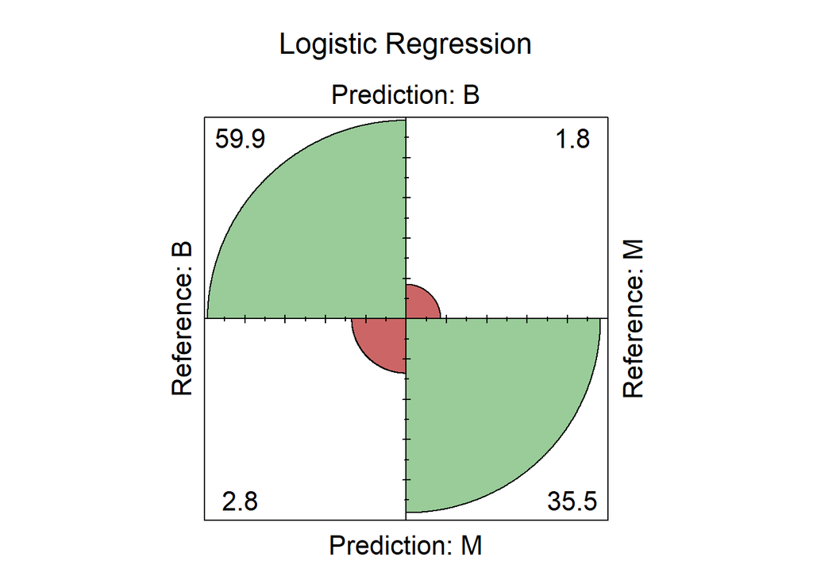

```
##                 Model  Accuracy    Recall Precision        FNR    Fscore
## 1 Logistic Regression 0.9543058 0.9528302 0.9266055 0.04716981 0.9395349
```

## k-Nearest Neighbours:

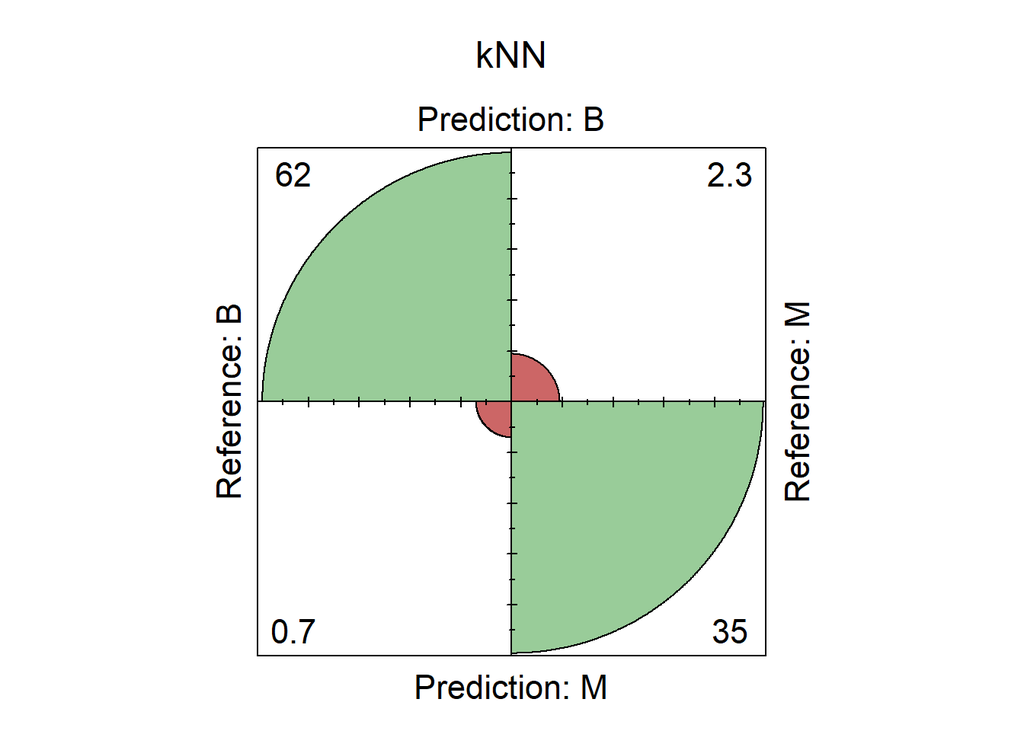

```
##   Model Accuracy    Recall Precision        FNR    Fscore
## 1  k-NN 0.970123 0.9386792 0.9802956 0.06132075 0.9590361
```

## Random Forest:

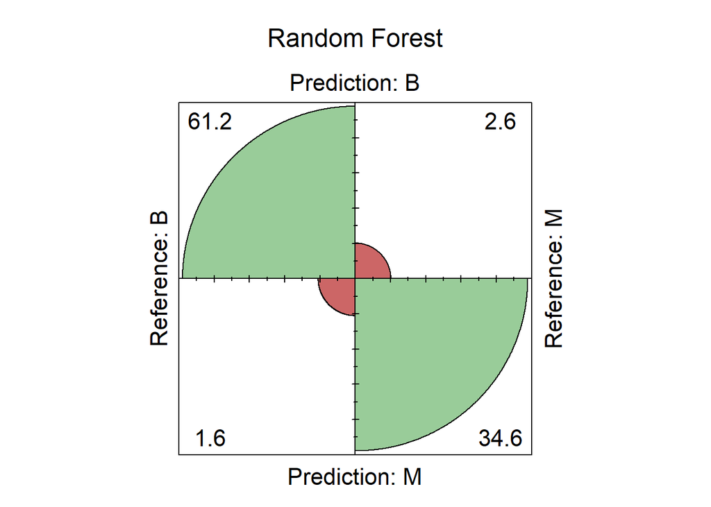

```
##           Model  Accuracy    Recall Precision        FNR    Fscore
## 1 Random Forest 0.9578207 0.9292453 0.9563107 0.07075472 0.9425837
```

## Model Performance - Confusion Matrices:

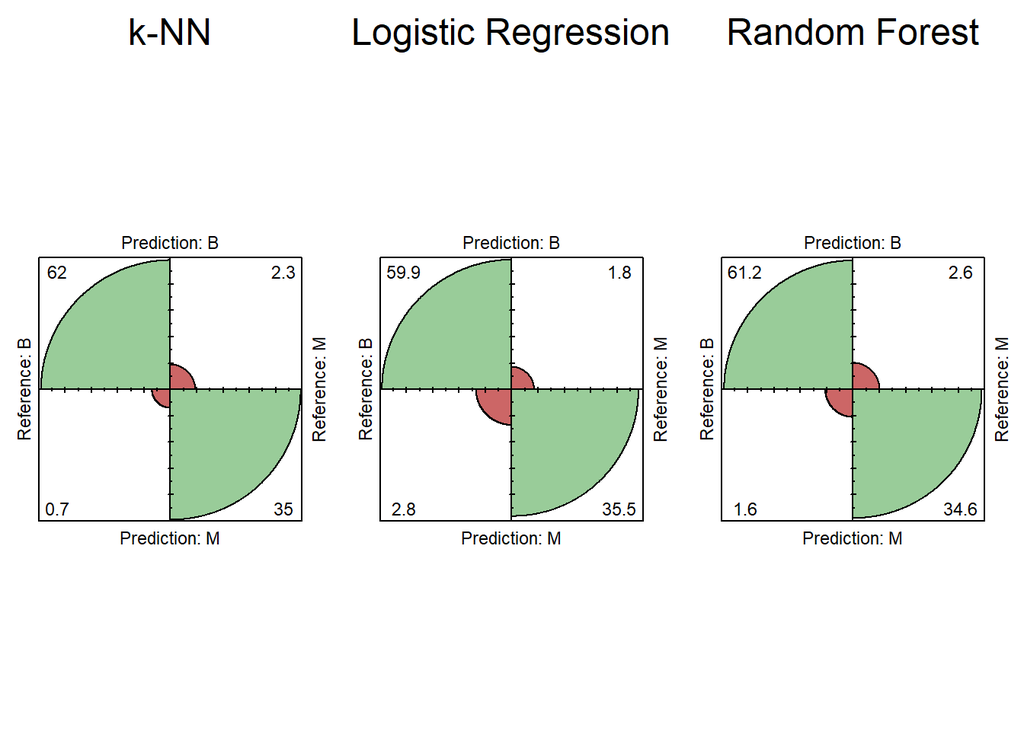

## Model Performance - Metrics:

```
##                 Model  Accuracy    Recall Precision        FNR    Fscore
## 1                k-NN 0.9701230 0.9386792 0.9802956 0.06132075 0.9590361
## 2 Logistic Regression 0.9543058 0.9528302 0.9266055 0.04716981 0.9395349
## 3       Random Forest 0.9578207 0.9292453 0.9563107 0.07075472 0.9425837
```

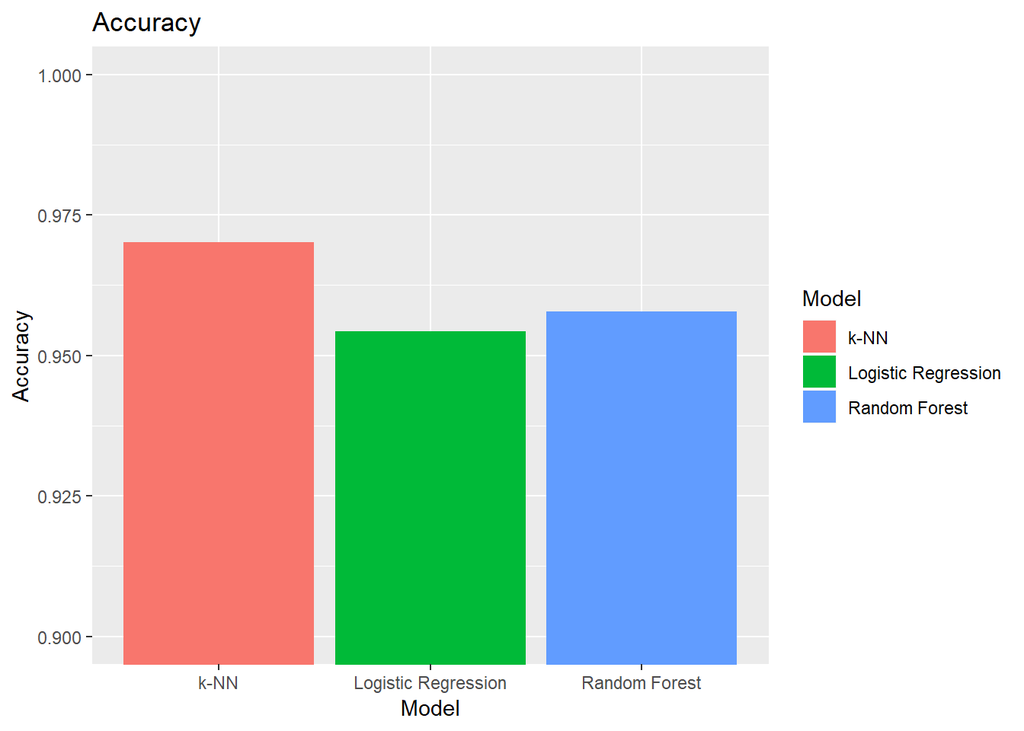

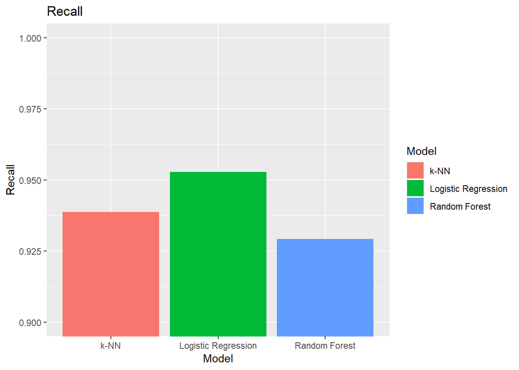

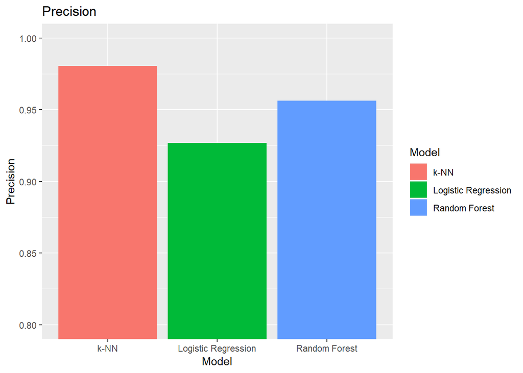

[figure not shown]

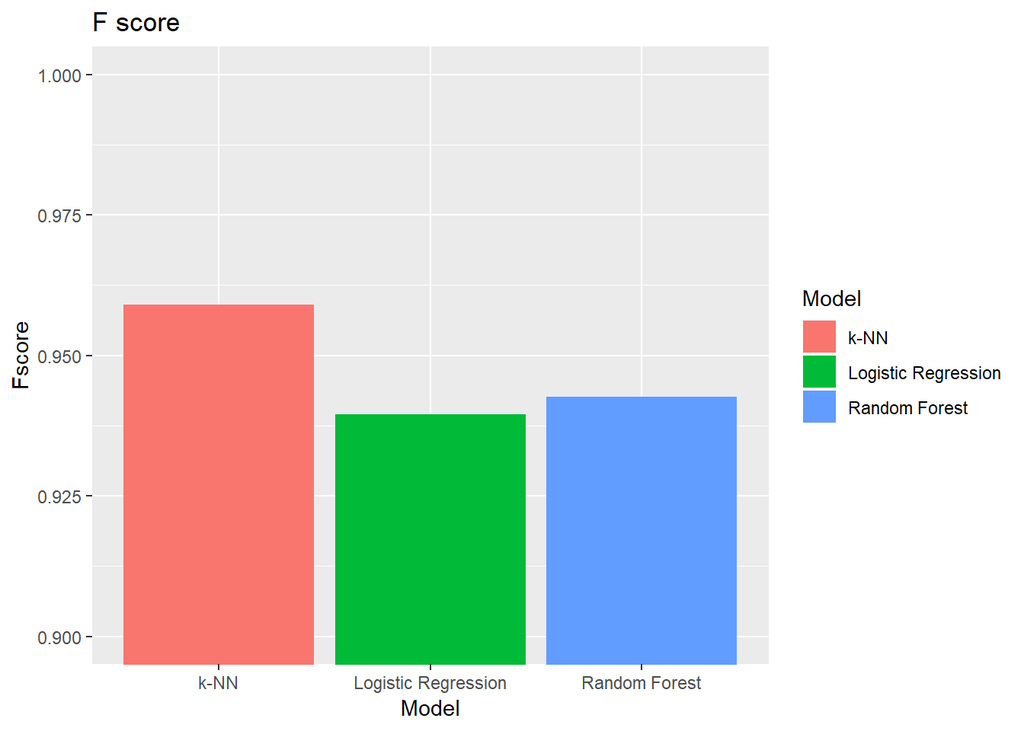